# Covariates in Time Series Models

21 Feb 2019

## Topics for today

### Covariates

- Why include covariates?
- Multivariate linear regression on time series data
- Covariates in MARSS models
  - Seasonality in MARSS models
  - Missing covariates

## Why include covariates in a model?

- We are often interested in knowing the cause of variation
- Covariates can explain the process that generated the patterns

[figure not shown]

## Why include covariates in a model?

- You want to forecast something using covariates

[figure not shown]

## Covariates -> Forecast

[figure not shown]

## Covariates in time series models

- Multivariate linear regression for time series data
- ARIMA models
  - Linear regression with ARIMA errors
  - ARMAX
- MARSS models with covariates
  - We will focus on this. Related to ARMAX

What about ETS and covariates? Wouldn’t make sense.

## Multivariate linear regression for time series data

Can you do a linear regression with time series data (response and predictors)? Yes, but you need to be careful. Read Chapter 5 in [Hyndman and Athanasopoulos 2018](https://otexts.com/fpp2/regression.html)

- Diagnostics that need to be satisfied
  - Residuals are temporally uncorrelated
  - Residuals are not correlated with the predictor variables
- Be careful regarding spurious correlation if both response and predictor variables have trends

## Autocorrelated response and predictor variables

Imagine that your data looked like so where the line is the data and the color represents your covariate.

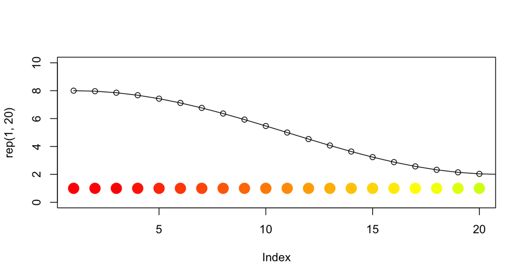

## Autocorrelated response and predictor variables

- Do you really have 20 independent data points for estimating the covariate effect?
- Why are the data correlated? It is only because of the covariate?
- How many covariates did you look at?
- This can be another type of spurious correlation.

## Linear regression with autocorrelated errors

The `xreg` argument in `Arima()` and `arima()` allows you to fit linear regressions with autocorrelated errors. Read Chapter 9 in [Hyndman and Athanasopoulos 2018](https://otexts.com/fpp2/dynamic.html) on Dynamic Regression.

A linear regression with autocorrelated errors is for example:

\[y_t = \alpha + \beta d_t + \nu_t \\ \nu_t = \theta_1 \nu_{t-1} + \theta_2 \nu_{t-2} + e_t\]

## Fitting in R

### `Arima()`

```
fit <- Arima(y, xreg=d, order=c(1,1,0))
```

### `auto.arima()`

```
fit <- auto.arima(y, xreg=x)
```

## Example from Hyndman and Athanasopoulos 2018

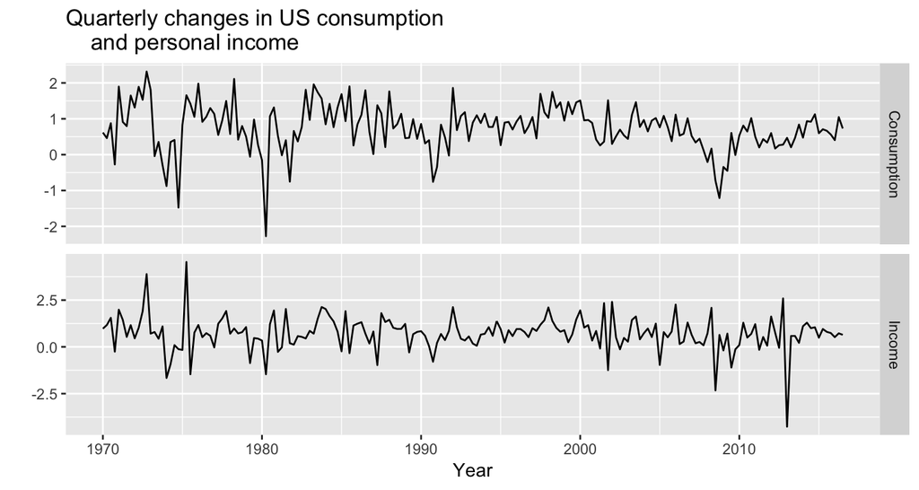

## A simple regression has problems

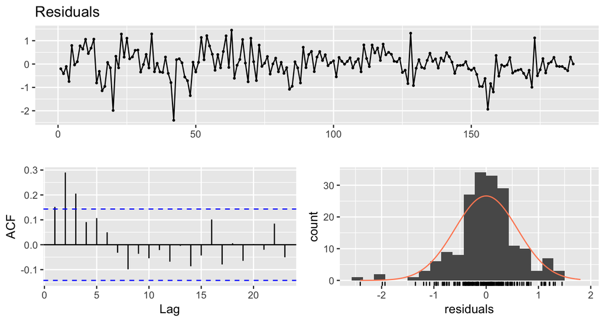

```
##
##  Breusch-Godfrey test for serial correlation of order up to 10
##
## data:  Residuals
## LM test = 27.584, df = 10, p-value = 0.002104
```

```r
y <- uschange[,"Consumption"]; d <- uschange[,"Income"]
fit <- lm(y~d)
checkresiduals(fit)
```

## Try AR(1) errors

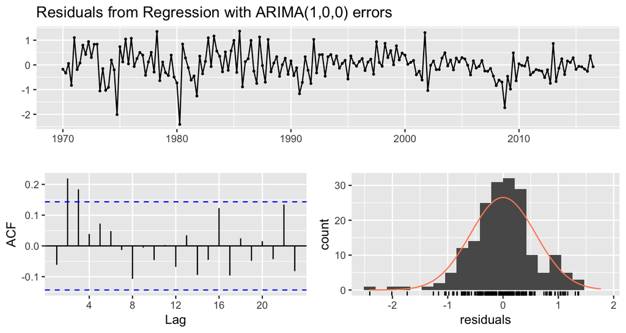

```
##
##  Ljung-Box test
##
## data:  Residuals from Regression with ARIMA(1,0,0) errors
## Q* = 20.485, df = 5, p-value = 0.001013
##
## Model df: 3.   Total lags used: 8
```

```r
fit <- Arima(y, xreg=d, order=c(1,0,0))
checkresiduals(fit)
```

## Let `auto.arima()` find best ARMA model

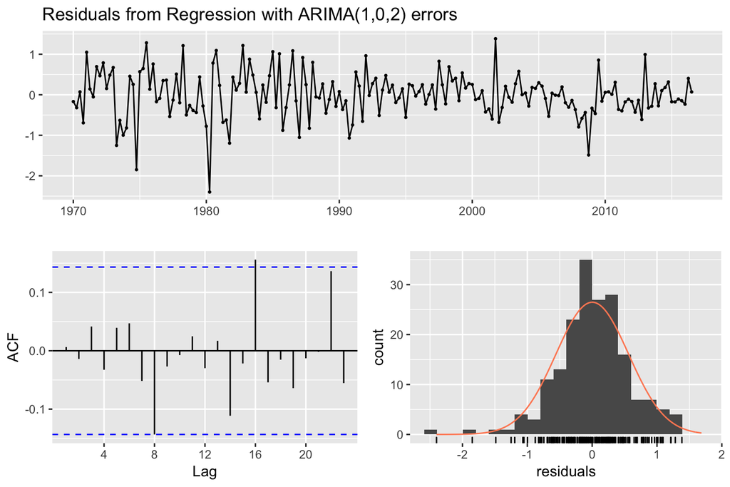

```
##
##  Ljung-Box test
##
## data:  Residuals from Regression with ARIMA(1,0,2) errors
## Q* = 5.8916, df = 3, p-value = 0.117
##
## Model df: 5.   Total lags used: 8
```

```r
fit <- auto.arima(y, xreg=d) # It finds a ARMA(1,0,2) is best.
checkresiduals(fit)
```

## Collinearity

The is a big issue. If you are thinking about stepwise variable selection, do a literature search on the issue. Read the chapter in [Holmes 2018: Chap 6](https://fish-forecast.github.io/Fish-Forecast-Bookdown/6-1-multivariate-linear-regression.html) on catch forecasting models using multivariate regression for a discussion of

- Stepwise variable regression in R
- Cross-validation for regression models
- Penalized regression in R
  - Lasso
  - Ridge
  - Elastic Net
- Diagnostics

## Covariates in MARSS models

We are trying to explain the ERRORS with our covariates.

\[\mathbf{x}_t = \mathbf{B} \mathbf{x}_{t-1} + \mathbf{C} \mathbf{c}_t + \mathbf{w}_t \\ \mathbf{y}_t = \mathbf{Z} \mathbf{x}_{t} + \mathbf{D} \mathbf{d}_t + \mathbf{v}_t\]